# Making plots with `ggplot2`: Barplots and Scatterplots

### Mapping Data to Color

#### Quick update to the dataset

```r
#code to update `mtcars` dataset so that `am` is treated as a factor rather than a continuous numeric variable
# used mutate and as.factor() to add column to existing dataset called am_factor

mtcars <- mtcars |>
  mutate(am_factor=as.factor(am))
```

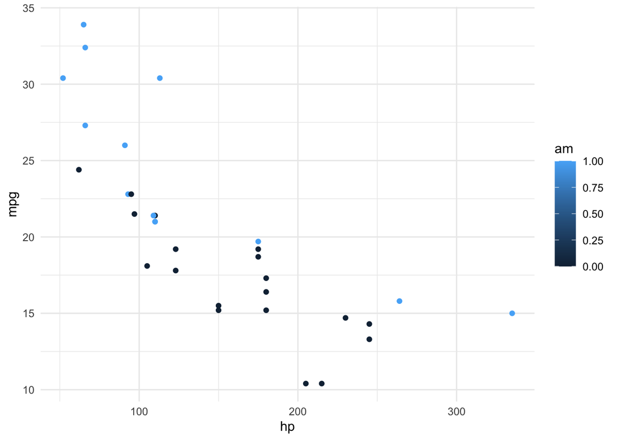

```r
# what is a factor and how does it change the plotting?

#plot using normal am

mtcars |>
  ggplot(aes(x=hp, y=mpg, color=am)) +
  geom_point() +
  theme_minimal()
```

Without turning `am` into a factor, it is plotted as a continuous variable with a color gradient for the variable.

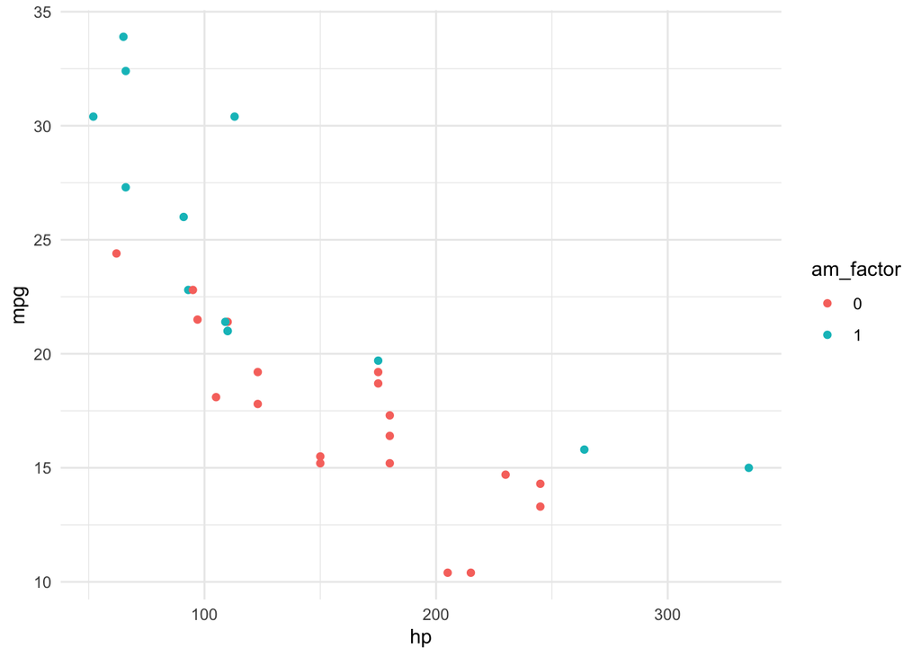

```r
#plot using am_factor

mtcars |>
  ggplot(aes(x=hp, y=mpg, color=am_factor)) +
  geom_point() +
  theme_minimal()
```

If we use the factor version (`am_factor`), it plots as a discrete variable. Where a single color is assigned to each category.

#### Customizing Colors in Aesthetics

You can customize the colors that you use for both discrete/categorical variables and continuous variables using the `scale_color_manual()` and `scale_color_gradient()` functions, respectively.

First we are going to take a look at how to define colors for a discrete variable using the `scale_color_manual()` function and the `am_factor` variable that we created above which takes on the value of either 0 or 1.

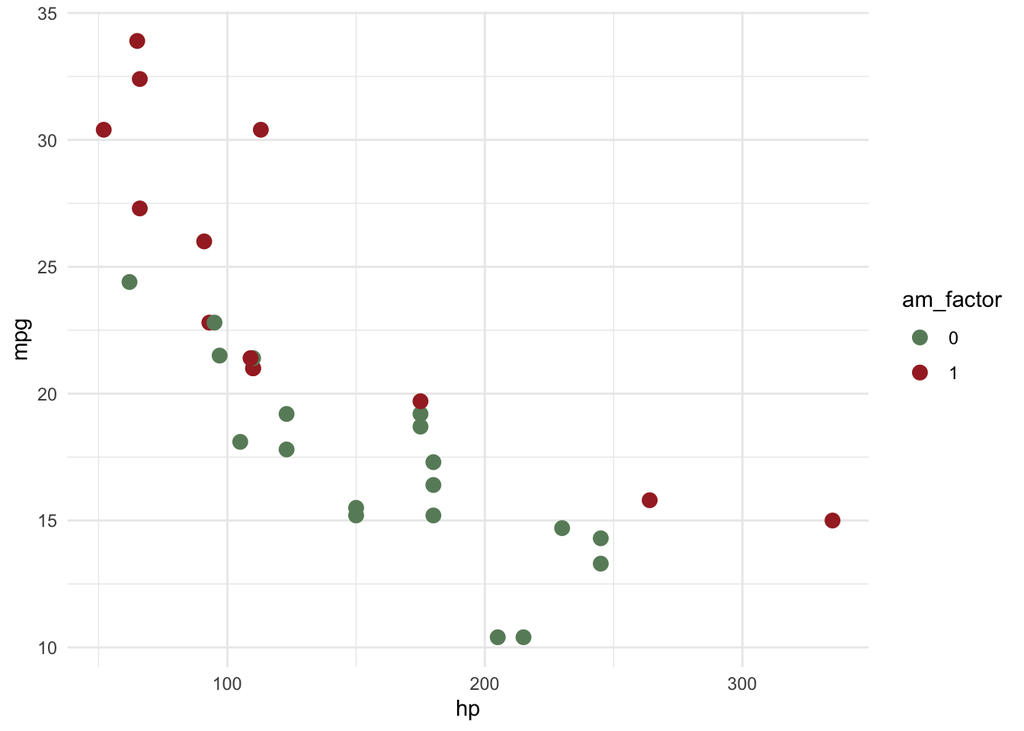

```r
# for discrete variables using scale_color_manual()

mtcars |>
  ggplot(aes(x=hp, y=mpg, color=am_factor)) +
  geom_point(size=3) +
  scale_color_manual(values=c("darkseagreen4","brown")) +
  theme_minimal()
```

We can also change the shape within the `aes()` function, and shape will be mapped to the two categories of `am_factor` in addition to color.

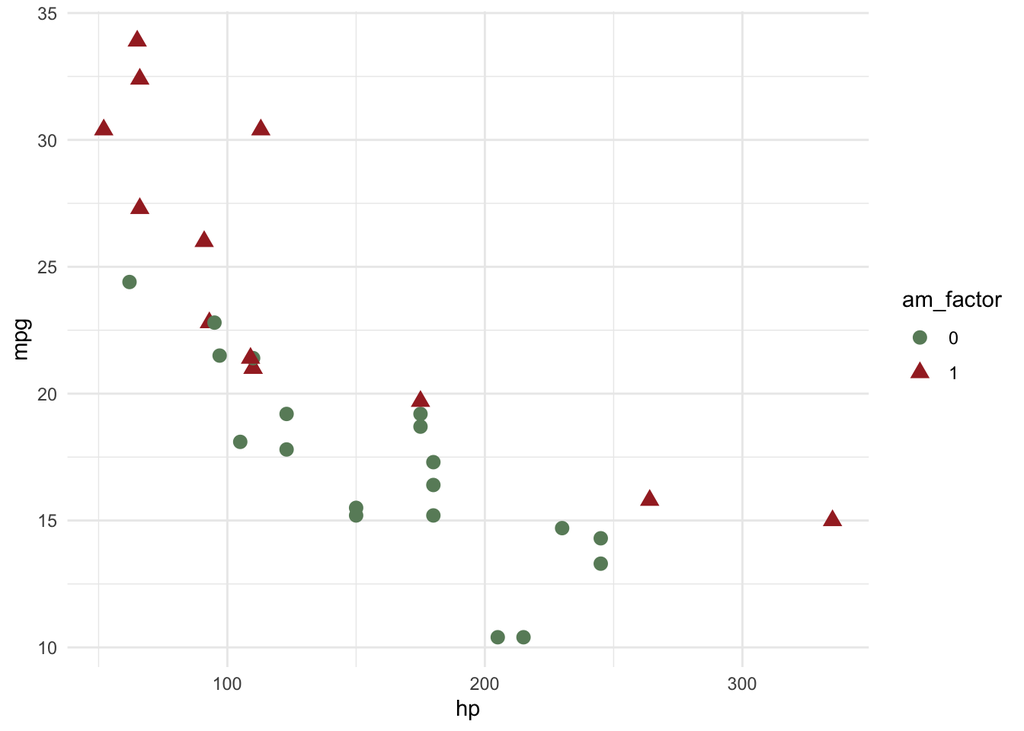

```r
# change shape within aes()

mtcars |>
  ggplot(aes(x=hp, y=mpg, color=am_factor, shape=am_factor)) +
  geom_point(size=3) +
  scale_color_manual(values=c("darkseagreen4","brown")) +
  theme_minimal()
```

Now let’s take a look at how to do this for a continuous variable using the `scale_color_gradient()` function that you should already have access to with the packages that you have loaded.

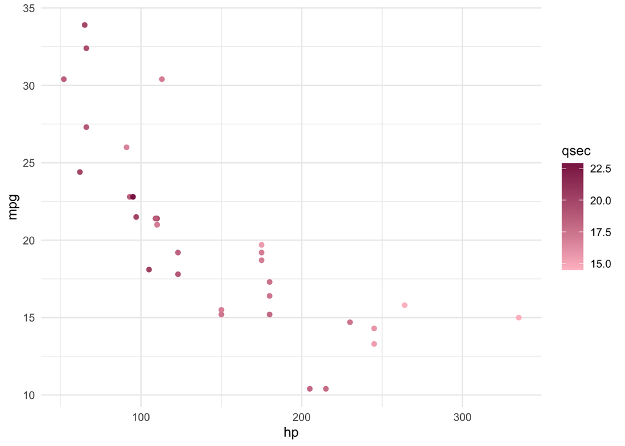

```r
# for continuous variables use scale_color_manual()

mtcars |>
  ggplot(aes(x=hp, y=mpg, color=qsec)) +
  geom_point() +
  scale_color_gradient(low="pink", high="violetred4") +
  theme_minimal()
```

There are lots of ways to control the colors and palette and we will get into how to operate more of those controls in a few classes.

**Tip**

- Use `scale_color_manual()` when assigning colors to categorical variables.
- Use `scale_color_gradient()` when assigning colors to continuous variables.

### Mapping Data to Shape

We can also map data to `shape`, just like we’ve done for `color`. Instead of using the `color` argument within the `aes()` function, we use the `shape` argument.

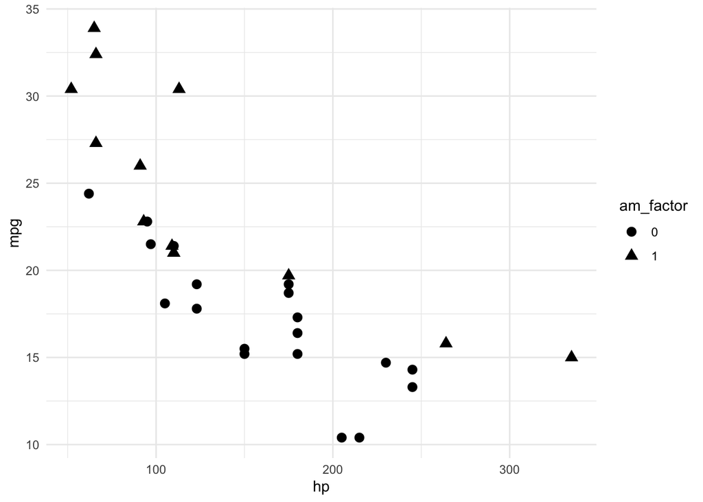

```r
mtcars |>
  ggplot(aes(x=hp, y=mpg, shape=am_factor)) +
  geom_point(size=3) +
  theme_minimal()
```

#### Customizing Shapes in Aesthetics

If you want to control which shape is mapped to which variable, you can use the `scale_shape_manual()` function, which operates very similarly to the `scale_color_manual()` function.

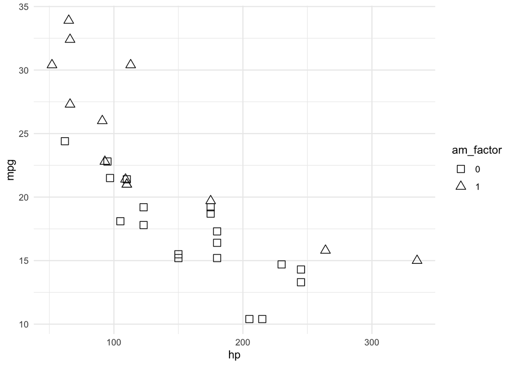

```r
# use the pch chart to find the numbers that correspond to different shapes

mtcars |>
  ggplot(aes(x=hp, y=mpg, shape=am_factor)) +
  geom_point(size=3) +
  scale_shape_manual(values = c(0, 2)) +
  theme_minimal()
```

If we want to control which variable is given which shape (this can be especially useful when you have more than just two categories), we can adjust our call to the `scale_shape_manual()` function like this:

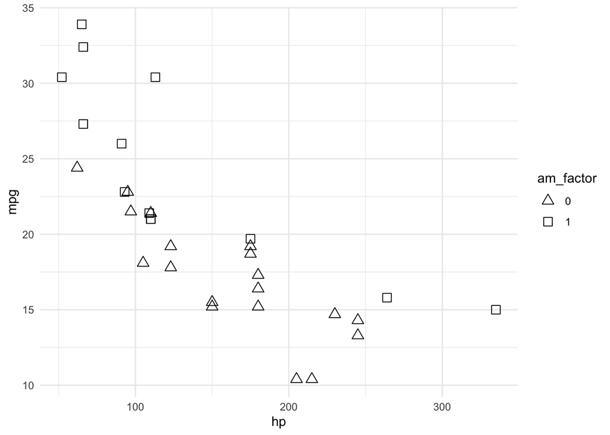

```r
# use the pch chart to find the numbers that correspond to different shapes

mtcars |>
  ggplot(aes(x=hp, y=mpg, shape=am_factor)) +
  geom_point(size=3) +
  scale_shape_manual(values = c("0" = 2, "1" = 0)) +
  theme_minimal()
```

*Hint: You can also control how colors are mapped to discrete variables using the same syntax inside of `scale_color_manual()`.*

## Global vs. Local Data and Aesthetics

Where you define your input data and `aes()` matters. Global aesthetic mappings apply to all geometries and can be defined when you initially call `ggplot()`. All the geometries added as layers will default to this mapping. Local aesthetic mappings add additional information or override the default mappings.

If we define our data mapping within the `geom_point()` function, additional geoms do not know anything about the mapping. We either have to define the mapping in each individual geom (locally):

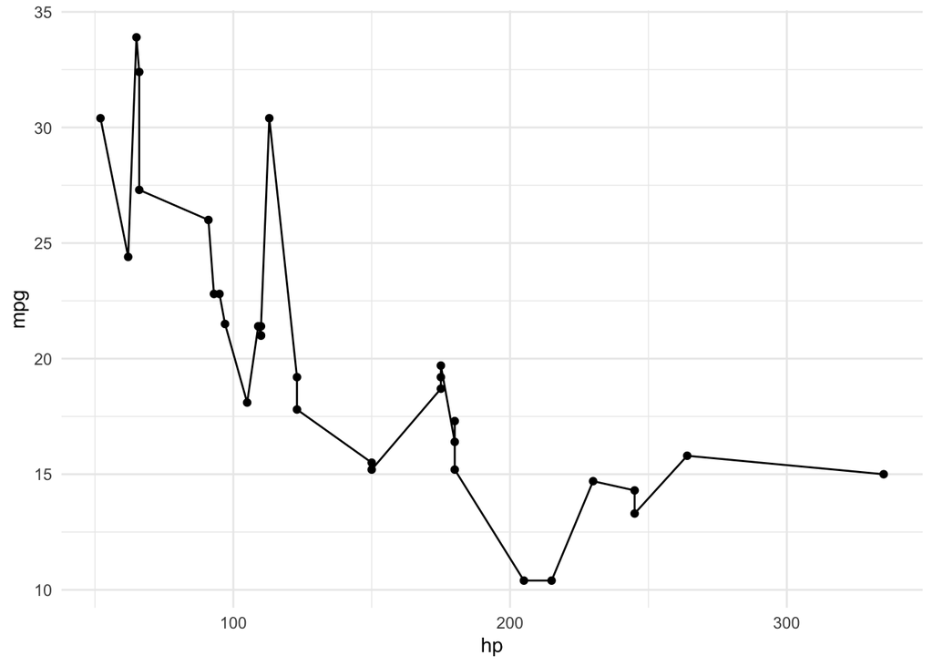

```r
#local variables
# geom_line() does not know about the data defined in geom_point()

# commented this figure out, because it is purposefully broken
# mtcars |>
#   ggplot() +
#   geom_point(aes(x=hp, y=mpg)) +
#   geom_line() +
#   theme_minimal()

  ggplot() +
  geom_point(data=mtcars, aes(x=hp, y=mpg)) +
  geom_line(data=mtcars, aes(x=hp, y=mpg)) +
  theme_minimal()
```

Or we need to define them at a higher level, inside the `ggplot()` function. This sets the mapping for all subsequent geoms, unless we explicitly say otherwise within the individual geoms:

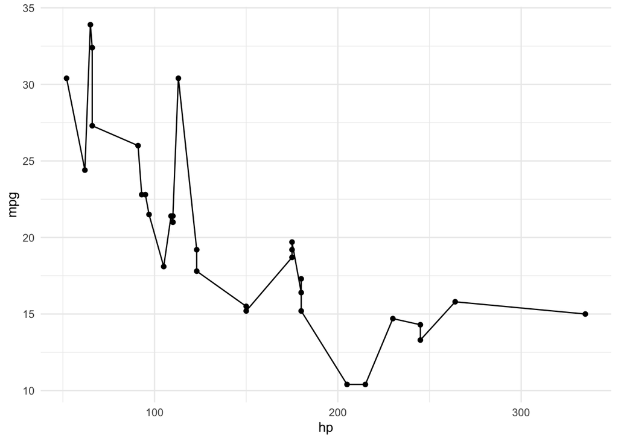

```r
# global variables
# if we define data and aesthetics in ggplot() every subsequent geom tht we call will know about them

mtcars |>
  ggplot(aes(x=hp, y=mpg)) +
  geom_point() +
  geom_line() +
  theme_minimal()
```

**Tip**

- If the thing you are trying to change (color, shape, size, etc.) depends on a variable, you should put in *inside* the aesthetics
- If the thing you are trying to change (color, shape, size, etc.) should happen for all things, you should not put it inside the aesthetics.

We can map a variable to `color` within the `aes()` function locally so that the `qsec` variable is only mapped to color for `geom_point()` and not to `geom_line()`.

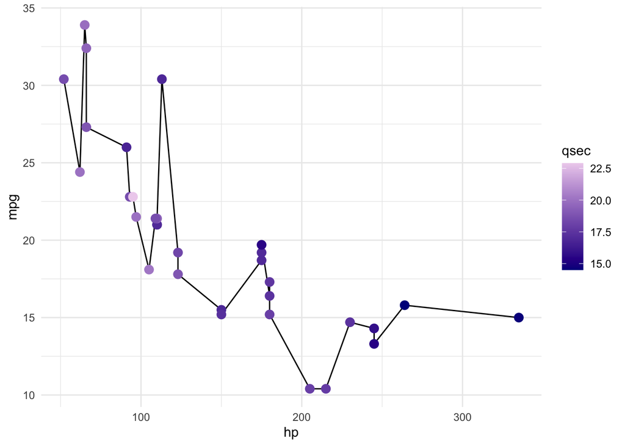

```r
#color = qsec as a local aesthetic
# set color gradient using scale_color_gradient()

mtcars |>
  ggplot(aes(x=hp, y=mpg)) +
  geom_line() +
  geom_point(aes(color=qsec), size=3) +
  scale_color_gradient(low="blue4", high="thistle2") +
  theme_minimal()
```

We can overwrite global data mapping by setting `color` to a single value locally outside `aes()` if we want to override the data mapping for `color` and set it to single color instead.

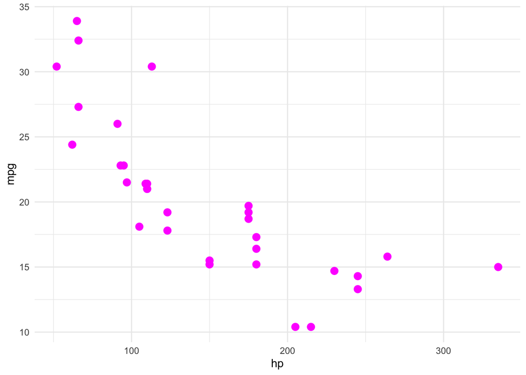

```r
# overwriting color = qsec as a global aesthetic with a local aesthetic in geom_point()

mtcars |>
  ggplot(mapping=aes(x=hp, y=mpg, color=qsec)) +
  geom_point(size=3, color="magenta") +
  scale_color_gradient(low="blue4", high="thistle2") +
  theme_minimal()
```

## In-Class Excercise:

### Plot 1

Create a scatterplot using `geom_point()` to explore the relationship between engine displacement (`disp`) and horsepower (`hp`) in the `mtcars` dataset. In addition to plotting these two numeric variables, *map a third numeric variable* of your choice to color. Apply a non-default continuous color scale using `scale_color_gradient()`, and include a clear title, axis labels, and a non-default theme. After creating your plot, write 2–3 sentences describing the pattern you observe between displacement and horsepower.

### Plot 2

Now extend the story by investigating a different relationship in the dataset. Choose two numeric variables other than `hp` and `disp` that you think might help explain fuel efficiency or vehicle performance, and create a new scatterplot using `geom_point()`. Convert one relevant grouping variable (such as `am`, `cyl`, or `gear`) to a factor and map it to color. Apply a non-default discrete color scale using `scale_color_manual()`, and include a clear title, axis labels, and a theme. In 2–3 sentences, explain why you chose these variables and what you observe in the plot.